# Lab 4 - Discretization

### **Name and id:** Roy Paz

using kaggle.json file from the first lab, load this lab's data:

You suppose to have 1 file:

imdb-data.zip

```python
! mkdir ~/.kaggle
! cp kaggle.json ~/.kaggle/
! chmod 600 ~/.kaggle/kaggle.json
! kaggle datasets download -d PromptCloudHQ/imdb-data
! unzip imdb-data.zip
```

```
mkdir: cannot create directory ‘/root/.kaggle’: File exists
Downloading imdb-data.zip to /content
100% 134k/134k [00:00<00:00, 361kB/s]
100% 134k/134k [00:00<00:00, 360kB/s]
Archive:  imdb-data.zip
  inflating: IMDB-Movie-Data.csv
```

Discretization is processs of taking continuous variables and transforming them into discrete variables.

Wannna know why? read more [here](https://medium.com/codex/data-discretization-b5faa2b77f06)

In this Lab we will apply two basic **unsupervised** discretization methods using pandas, and one **supervised** method.

## About the data

The dataset hold the [Top '06 - '16 Films from IMDB](https://www.kaggle.com/datasets/PromptCloudHQ/imdb-data).

Today we will try discretization methods on the numerical attributes of the dataset.

```python
import pandas as pd
import matplotlib.pyplot as plt
import seaborn as sns

df=pd.read_csv('IMDB-Movie-Data.csv' , index_col=  'Rank')
numeric_att =['Year', 'Runtime (Minutes)' ,	'Rating' ,	'Votes' ,	'Revenue (Millions)' ,	'Metascore']
df[numeric_att] = df[numeric_att].apply(pd.to_numeric, errors = 'coerce')
df.head(5)
```

| Rank | Title | Genre | Description | Director | Actors | Year | Runtime (Minutes) | Rating | Votes | Revenue (Millions) | Metascore |
| --- | --- | --- | --- | --- | --- | --- | --- | --- | --- | --- | --- |
| 1 | Guardians of the Galaxy | Action,Adventure,Sci-Fi | A group of intergalactic criminals are forced ... | James Gunn | Chris Pratt, Vin Diesel, Bradley Cooper, Zoe S... | 2014 | 121 | 8.1 | 757074 | 333.13 | 76.0 |
| 2 | Prometheus | Adventure,Mystery,Sci-Fi | Following clues to the origin of mankind, a te... | Ridley Scott | Noomi Rapace, Logan Marshall-Green, Michael Fa... | 2012 | 124 | 7.0 | 485820 | 126.46 | 65.0 |
| 3 | Split | Horror,Thriller | Three girls are kidnapped by a man with a diag... | M. Night Shyamalan | James McAvoy, Anya Taylor-Joy, Haley Lu Richar... | 2016 | 117 | 7.3 | 157606 | 138.12 | 62.0 |
| 4 | Sing | Animation,Comedy,Family | In a city of humanoid animals, a hustling thea... | Christophe Lourdelet | Matthew McConaughey,Reese Witherspoon, Seth Ma... | 2016 | 108 | 7.2 | 60545 | 270.32 | 59.0 |
| 5 | Suicide Squad | Action,Adventure,Fantasy | A secret government agency recruits some of th... | David Ayer | Will Smith, Jared Leto, Margot Robbie, Viola D... | 2016 | 123 | 6.2 | 393727 | 325.02 | 40.0 |

The current distribution of the **'Revenue (Millions)'** attribute is:

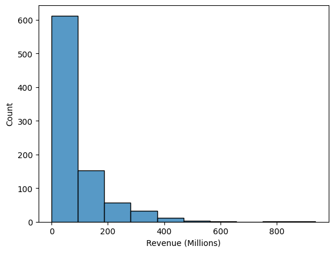

```python
g= sns.histplot(data = df, x = 'Revenue (Millions)' , bins = 10)
```

## **Unsupervised Discretization Methods**

Many Methods exists, we will explore two basic ones - Equal width and Equal frequency.

## **Equal Width**

Split the numeric attribute to n bins - every bin should have the same length.

## Task 1:

using pandas [cut](https://pandas.pydata.org/pandas-docs/stable/reference/api/pandas.cut.html) method, split the **'Revenue (Millions)'** attribute into Equal width bins of size 10.

Hint - That exactly what sns.histplot does, as plotted above.

Print the resulting bins thresholds.

```python
df['Revenue_cut'] = pd.cut(df['Revenue (Millions)'], bins=10)
df['Revenue_cut']
```

```
Rank
1       (280.989, 374.652]
2        (93.663, 187.326]
3        (93.663, 187.326]
4       (187.326, 280.989]
5       (280.989, 374.652]
               ...
996                    NaN
997       (-0.937, 93.663]
998       (-0.937, 93.663]
999                    NaN
1000      (-0.937, 93.663]
Name: Revenue_cut, Length: 1000, dtype: category
Categories (10, interval[float64, right]): [(-0.937, 93.663] < (93.663, 187.326] <
                                            (187.326, 280.989] < (280.989, 374.652] < ... <
                                            (561.978, 655.641] < (655.641, 749.304] <
                                            (749.304, 842.967] < (842.967, 936.63]]
```

## **Equal Frequency**

Split the numeric attribute to n bins - every bin should be the **same size** (number of records).

Take notice - the bins should be approximately the same size, usually the data isn't rich enough for equal partition.

## Task 2:

using pandas [qcut](https://pandas.pydata.org/pandas-docs/stable/reference/api/pandas.qcut.html) method, split the **'Revenue (Millions)'** attribute into 10 Equal frequency bins.

Plot the resulting bins.

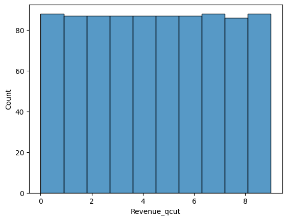

```python
df['Revenue_qcut'] = pd.qcut(x= df['Revenue (Millions)'], q= 10, labels=False)
sns.histplot(data=df, x='Revenue_qcut', bins=10)
```

## Task 3:

Pandas cut method can split numerical attributes to non - equal bins.

Hint - use bins and labels arguments.

```python
bins = [0, 5, 7.5, 10]
labels = ['bad', 'mid', 'great']
df['Rating_labels'] = pd.cut(x= df['Rating'], bins= bins, labels=labels)
df
```

| Rank | Title | Genre | Description | Director | Actors | Year | Runtime (Minutes) | Rating | Votes | Revenue (Millions) | Metascore | Revenue_cut | Revenue_qcut | Rating_labels |
| --- | --- | --- | --- | --- | --- | --- | --- | --- | --- | --- | --- | --- | --- | --- |
| 1 | Guardians of the Galaxy | Action,Adventure,Sci-Fi | A group of intergalactic criminals are forced ... | James Gunn | Chris Pratt, Vin Diesel, Bradley Cooper, Zoe S... | 2014 | 121 | 8.1 | 757074 | 333.13 | 76.0 | (280.989, 374.652] | 9.0 | great |
| 2 | Prometheus | Adventure,Mystery,Sci-Fi | Following clues to the origin of mankind, a te... | Ridley Scott | Noomi Rapace, Logan Marshall-Green, Michael Fa... | 2012 | 124 | 7.0 | 485820 | 126.46 | 65.0 | (93.663, 187.326] | 7.0 | mid |
| 3 | Split | Horror,Thriller | Three girls are kidnapped by a man with a diag... | M. Night Shyamalan | James McAvoy, Anya Taylor-Joy, Haley Lu Richar... | 2016 | 117 | 7.3 | 157606 | 138.12 | 62.0 | (93.663, 187.326] | 8.0 | mid |
| 4 | Sing | Animation,Comedy,Family | In a city of humanoid animals, a hustling thea... | Christophe Lourdelet | Matthew McConaughey,Reese Witherspoon, Seth Ma... | 2016 | 108 | 7.2 | 60545 | 270.32 | 59.0 | (187.326, 280.989] | 9.0 | mid |
| 5 | Suicide Squad | Action,Adventure,Fantasy | A secret government agency recruits some of th... | David Ayer | Will Smith, Jared Leto, Margot Robbie, Viola D... | 2016 | 123 | 6.2 | 393727 | 325.02 | 40.0 | (280.989, 374.652] | 9.0 | mid |
| ... | ... | ... | ... | ... | ... | ... | ... | ... | ... | ... | ... | ... | ... | ... |
| 996 | Secret in Their Eyes | Crime,Drama,Mystery | A tight-knit team of rising investigators, alo... | Billy Ray | Chiwetel Ejiofor, Nicole Kidman, Julia Roberts... | 2015 | 111 | 6.2 | 27585 | NaN | 45.0 | NaN | NaN | mid |
| 997 | Hostel: Part II | Horror | Three American college students studying abroa... | Eli Roth | Lauren German, Heather Matarazzo, Bijou Philli... | 2007 | 94 | 5.5 | 73152 | 17.54 | 46.0 | (-0.937, 93.663] | 2.0 | mid |
| 998 | Step Up 2: The Streets | Drama,Music,Romance | Romantic sparks occur between two dance studen... | Jon M. Chu | Robert Hoffman, Briana Evigan, Cassie Ventura,... | 2008 | 98 | 6.2 | 70699 | 58.01 | 50.0 | (-0.937, 93.663] | 5.0 | mid |
| 999 | Search Party | Adventure,Comedy | A pair of friends embark on a mission to reuni... | Scot Armstrong | Adam Pally, T.J. Miller, Thomas Middleditch,Sh... | 2014 | 93 | 5.6 | 4881 | NaN | 22.0 | NaN | NaN | mid |
| 1000 | Nine Lives | Comedy,Family,Fantasy | A stuffy businessman finds himself trapped ins... | Barry Sonnenfeld | Kevin Spacey, Jennifer Garner, Robbie Amell,Ch... | 2016 | 87 | 5.3 | 12435 | 19.64 | 11.0 | (-0.937, 93.663] | 3.0 | mid |

1000 rows × 14 columns

## Supervised

A basic step in the Info-Fuzzy Network construciton procedure is the Conditional Mutual Information calculation per Node.

The procedure finds the best threhold to split an ordinal attribute based on the target attribute.

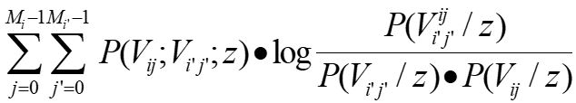

Below is a code snippet that calculates the Conditional Mutual Information between a input and output columns.

```python
import numpy as np
def mutual_information(data, input, target):

        mi = 0

        # Calculate frequency table of X, Y, and XY
        P_X = data.groupby(input).size()
        P_X = P_X/P_X.sum()

        P_Y = data.groupby(target).size()
        P_Y = P_Y/P_Y.sum()

        P_XY = data.groupby([input,target]).size()
        P_XY = P_XY/P_XY.sum()
        # Calculate Mutual Information
        for ind in P_XY.index:

            x_ind = pd.Index((ind[0],), name = input)
            y_ind = pd.Index((ind[1],), name = target)
            xy_ind = pd.MultiIndex.from_tuples([ind], names =[input,target])

            if P_XY[xy_ind].item() != 0 :
              mi += P_XY[xy_ind].item() * np.log2(P_XY[xy_ind].item()/(P_X[x_ind].item() * P_Y[y_ind].item()))

        return mi
```

Whom parameters are:

- data - pandas DataFrame
- input, target - strings, names of the input and target columns respectivly.

Running Example, based on Loan attributes from Classes:

```python
#Building the arrays in accordance with the occurance frequencies
a , b, c, d = 306 , 23 , 77 , 284

input = [0] * (a+b) + [1] * (c + d)
target = [0] * a + [1] * b + [0] * c + [1] *d

#inserting into a dataset
data = pd.DataFrame([] , columns =['input' , 'target'])
data['input'] = input
data['target'] = target

##Calculating mutual information
mutual_information(data , 'input' , 'target')
```

```
0.42570942667282563
```

## Task 4:

print the threshold value, and the mutual information.

Advice -

- Iterate over all distinct values in the input attribute
- transform a copy of the input attribute to a binary attribute - based on the threshold.

```python
best_split = None
best_mi = -1
for val in df['Runtime (Minutes)'].unique():
    df[f'Runtime (Minutes)_bin_{val}'] = (df['Runtime (Minutes)'] > val).astype(int)
    mi = mutual_information(df, f'Runtime (Minutes)_bin_{val}', 'Rating')
    if mi > best_mi:
      best_split = val
      best_mi = mi

print(f'Best split value: {best_split}')
print(f'Corresponding mutual information: {best_mi}')
```

```
Best split value: 115
Corresponding mutual information: 0.12192375809356461
```

## Task 5:

Convert the notebook into html:

1. Download the notebook by clicking the File tab
2. Upload it to this environment
3. Run the command:

```python
%%shell
jupyter nbconvert --to html Lab4.ipynb
```

[output not shown]

[output cut: 133 more lines]

[output not shown]

[output not shown]